# Score Simulation

Matt

23 March 2017

## Estimating Current Score

The British Orienteering Federation method of ranking is the most widely recognised, the IOF have subsequently taken it on board. Australia and New Zealand also use the same method with variation.

Essentially all orienteers have a set of current scores for a 12 month window. Each race is scored and the best 6 (5 for for New Zealand) contribute to your ranking. Races are considered for ranking if they have 10 complete runs, ie excluding DNFs, DQs and MPs. The bottom 10% are also discarded for part of the calculation.

All this document is designed to do is look at different numbers and proportions to see if 10 and the 90th percentile are suited to NZ or can we use different value and get the same current score for an event/race.

New Zealand Rankings have been kept at StatNav since 2014. As at Februrary 2017 the top of the table is as follows, with Nick Hann at the top.

```
##            FullName Club SS Sex  YoB OIK Grade Count Score Diff
## 1          NickHann   PP  S   M 1994  13   M21    15  7236   -6
## 2     GeneBeveridge   NW  N   M 1991   7   M21    21  7200   13
## 3         MattOgden   NW  N   M 1992   6   M21    16  7197   24
## 4        ChrisForne   PP  S   M 1976 765   M40    10  7152   21
## 5 CarstenJoergensen   PP  S   M 1970  11   M45    20  7084    0
## 6        TommyHayes   AK  N   M 1997 883   M20    17  7076   59
```

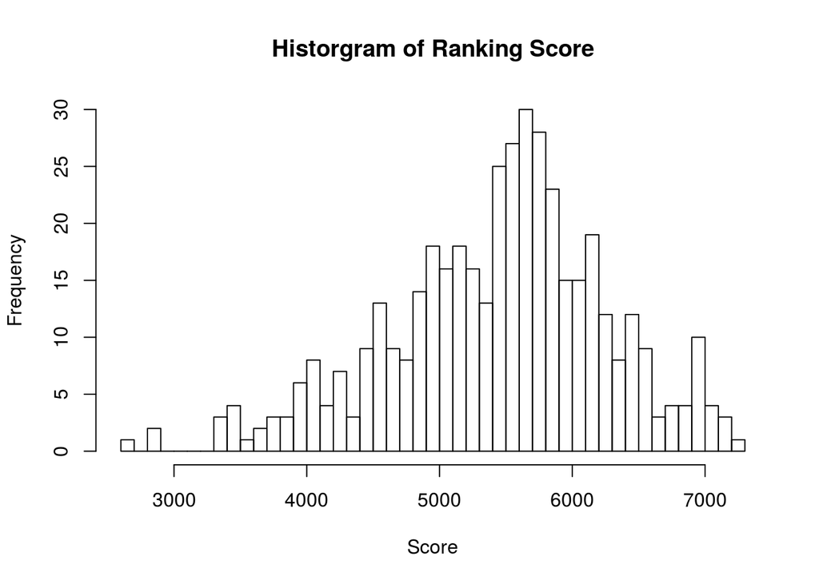

I used the rankings to generate a set of “Current” scores. The ranking score is the best 5 of your results, I then estimated another 5 results such that the overall mean and standard deviation were 1000 and 200 respectively. That was simply subtracting 2x the mean of the Current Score based on the Ranking Score. Additionally a number of other races were added to test the over all system. This gave the table of current scores to be used in the simulation

```
##          FullName      NA.    NA..1    NA..2    NA..3    NA..4    NA..5
## 1     AaronPrince       NA       NA       NA       NA       NA       NA
## 2 AdrianGriffiths 887.1260 887.1260 887.1260 887.1260 887.1260 1070.987
## 3      AlanDobson 932.2554 932.2554 932.2554 932.2554 932.2554 1116.116
## 4       AlanMoore 940.1948 940.1948 940.1948 940.1948 940.1948 1124.055
## 5   AlCory-Wright       NA       NA       NA       NA       NA       NA
## 6    AleishaNeary 929.1214 929.1214 929.1214 929.1214 929.1214 1112.982
```

Mean = **1000** and Standard Deviation = **200** as expected.

The score for a given race is calculated as follows

RT = Time in minutes  
MT = Mean race time for ALL runners  
ST = Standard Deviation of ALL runners times  
RP = Race Points

MP and SP are the mean and standard deviation of the CURRENT scores (all, not just best 5) for the top 90% of the field. It is this values that I will be changing for the race I’ve selected. Of most interest is the effect of including more runners, ie the the tail of the field, so 95% and 100%.

$$RP = SP*\frac{(MT-RT)}{ST} + MP$$